# Exploratory Data Analysis Quizz 2

# Question 1

Under the lattice graphics system, what do the primary plotting functions like xyplot() and bwplot() return?

```r
x <- rnorm(500,4,1)
y <- x+rnorm(500,1,1)

library(lattice)
xyClass <- xyplot(x~y)
class(xyClass)
```

```
## [1] "trellis"
```

object of class “trellis”

# Question 2

What is produced by the following code?

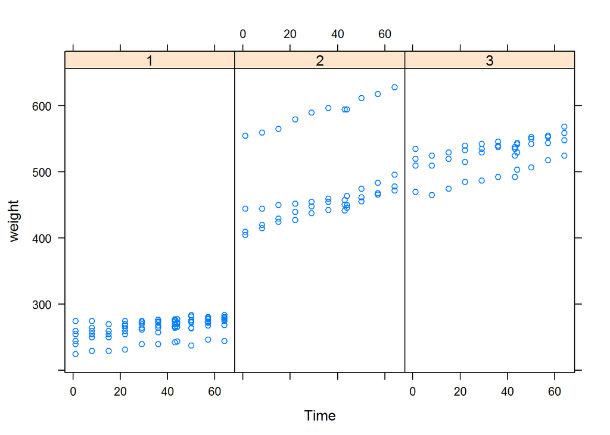

```r
library(nlme)
library(lattice)
xyplot(weight ~ Time | Diet, BodyWeight)
```

A set of 3 panels showing the relationship between weight and time for each diet.

# Question 3

Annotation of plots in any plotting system involves adding points, lines, or text to the plot, in addition to customizing axis labels or adding titles. Different plotting systems have different sets of functions for annotating plots in this way. Which of the following functions can be used to annotate the panels in a multi-panel lattice plot?

```r
?llines
```

llines()

# Question 4

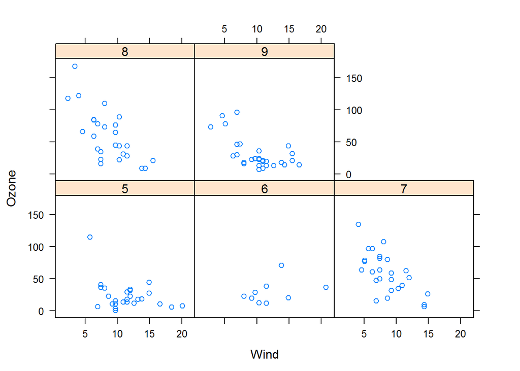

```r
library(lattice)
library(datasets)
data(airquality)
p <- xyplot(Ozone ~ Wind | factor(Month), data = airquality)
print(p)
```

# Question 5

In the lattice system, which of the following functions can be used to finely control the appearance of all lattice plots?

```r
?trellis.par.set
```

trellis.par.set

# Question 6

What is ggplot2 an implementation of?

the Grammar of Graphics developed by Leland Wilkinson [Wikipedia GGPLOT2](http://en.wikipedia.org/wiki/Ggplot2)

# Question 7

Load the `airquality’ dataset form the datasets package in R. I am interested in examining how the relationship between ozone and wind speed varies across each month. What would be the appropriate code to visualize that using ggplot2?

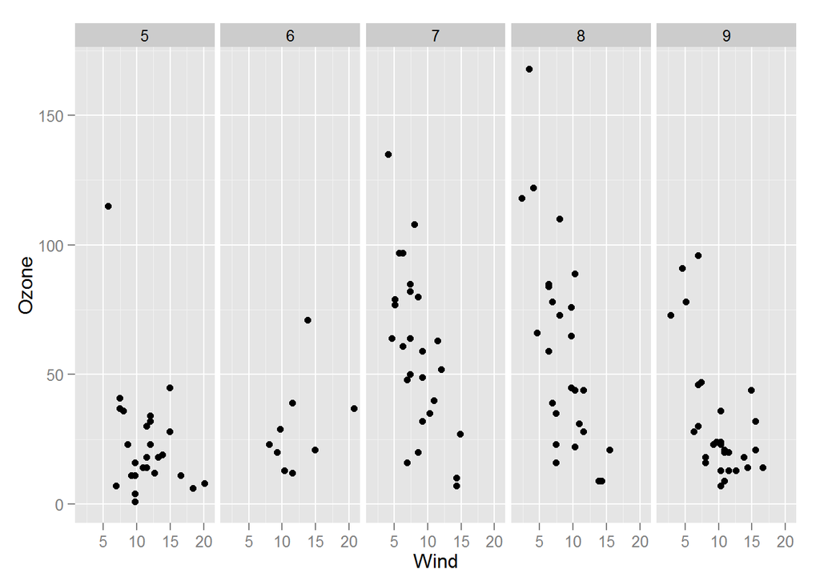

```r
library(datasets)
library(ggplot2)
data(airquality)

airquality = transform(airquality, Month = factor(Month))
qplot(Wind, Ozone, data = airquality, facets = . ~ Month)
```

# Question 8

What is a geom in the ggplot2 system?

```r
??geom
```

a plotting object like point, line, or other shape

# Question 9

When I run the following code I get an error: I was expecting a scatterplot of ‘votes’ and ‘rating’ to appear. What’s the problem?

```r
library(ggplot2)
g <- ggplot(movies, aes(votes, rating))
print(g)
```

ggplot does not yet know what type of layer to add to the plot.

# Question 10

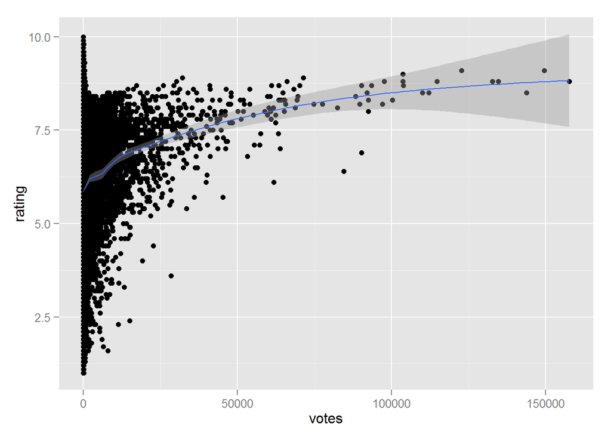

```r
qplot(votes, rating, data = movies) + geom_smooth()
```